# ggplot2 Elegant Graphics for Data Analysis

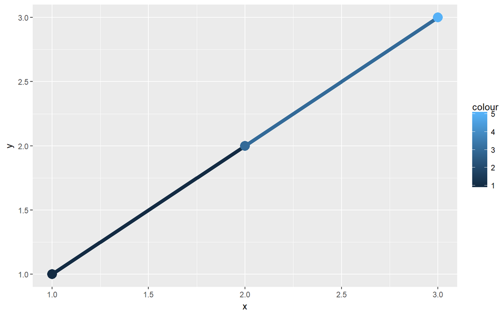

```r
ggplot(df, aes(x, y, colour = colour)) +
  geom_line(aes(group = 1), size = 2) +
  geom_point(size = 5)
```

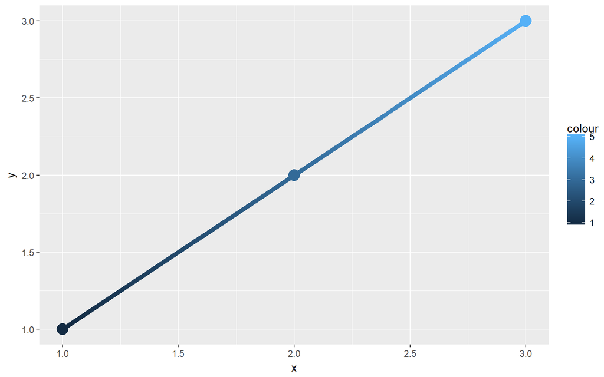

```r
xgrid <- with(df, seq(min(x), max(x), length = 50))
  interp <- data.frame(
  x = xgrid,
  y = approx(df$x, df$y, xout = xgrid)$y,
  colour = approx(df$x, df$colour, xout = xgrid)$y
)
ggplot(interp, aes(x, y, colour = colour)) +
  geom_line(size = 2) +
  geom_point(data = df, size = 5)
```

default goruping 이 class(이산형변수)를 바탕으로 하고 있기 때문에 연속형 변수를 fill에 mapping 시킬려면 group을 바꿔줘야 한다.

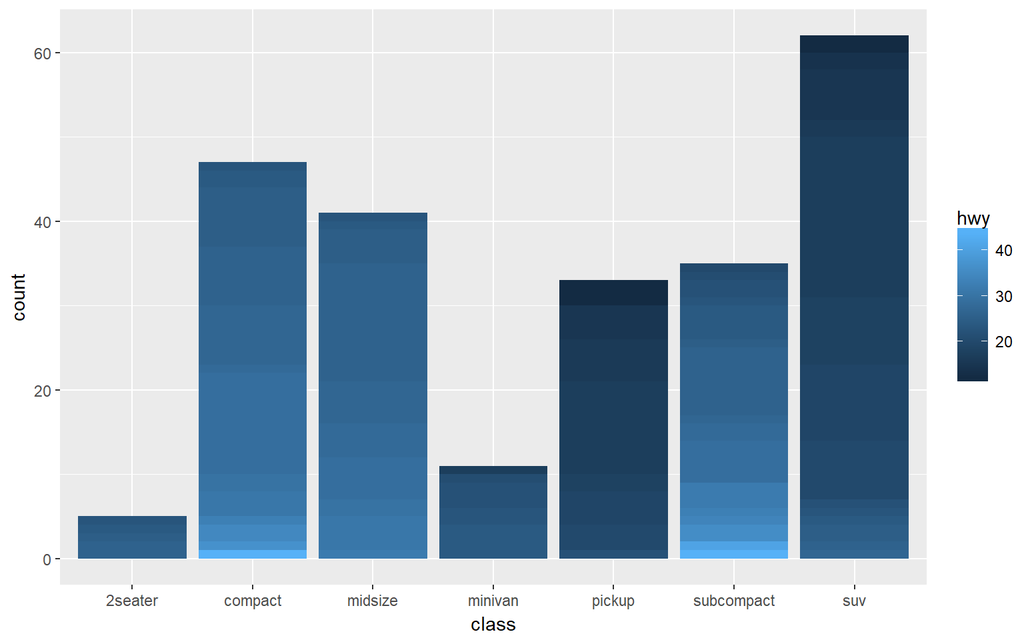

```r
ggplot(mpg, aes(class, fill = hwy, group = hwy)) + #group = hwy 를 반드시 설정해준다.
  geom_bar()
```

섬세한 컨트롤을 원하면 순서형 펙터를 만들자.

## 4.1 Exercises

Modify the following plot so that you get one boxplot per integer value of displ. ggplot(mpg, aes(displ, cty)) + geom_boxplot()

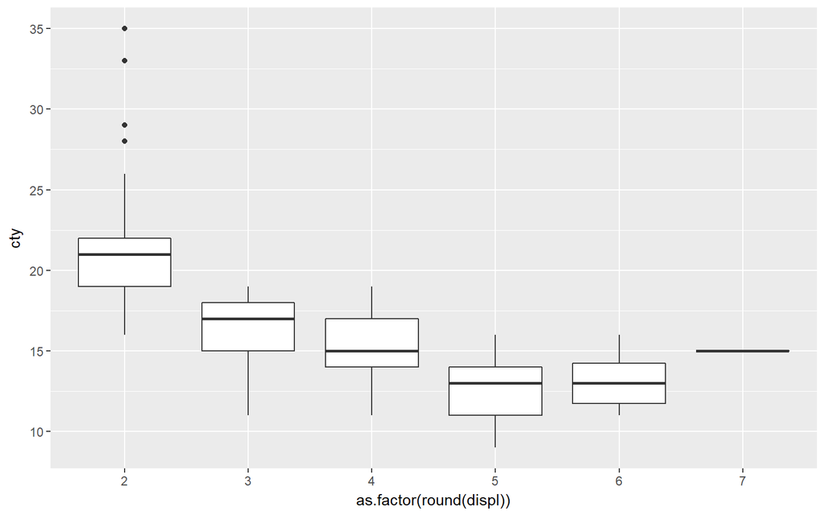

```r
ggplot(mpg, aes(as.factor(round(displ)), cty)) +
 geom_boxplot()
```

```r
as.integer(1.6) # 소수점 삭제, integer
```

```
## [1] 1
```

```r
floor(1.6)
```

```
## [1] 1
```

```r
round(1.6)
```

```
## [1] 2
```

```r
class(floor(1.6)) # numeric
```

```
## [1] "numeric"
```

How many bars are in each of the following plots? ggplot(mpg, aes(drv)) + geom_bar() ggplot(mpg, aes(drv, fill = hwy, group = hwy)) + geom_bar() library(dplyr) mpg2 <- mpg %>% arrange(hwy) %>% mutate(id = seq_along(hwy)) ggplot(mpg2, aes(drv, fill = hwy, group = id)) + geom_bar() (Hint: try adding an outline around each bar with colour = “white”)

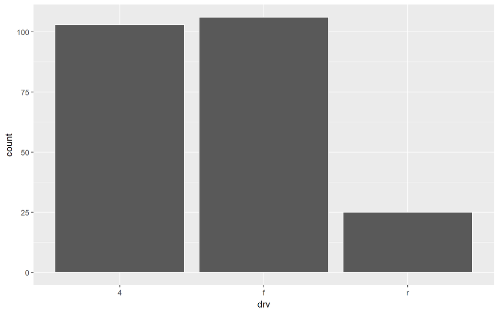

```r
ggplot(mpg, aes(drv)) +
  geom_bar(colour = "white")
```

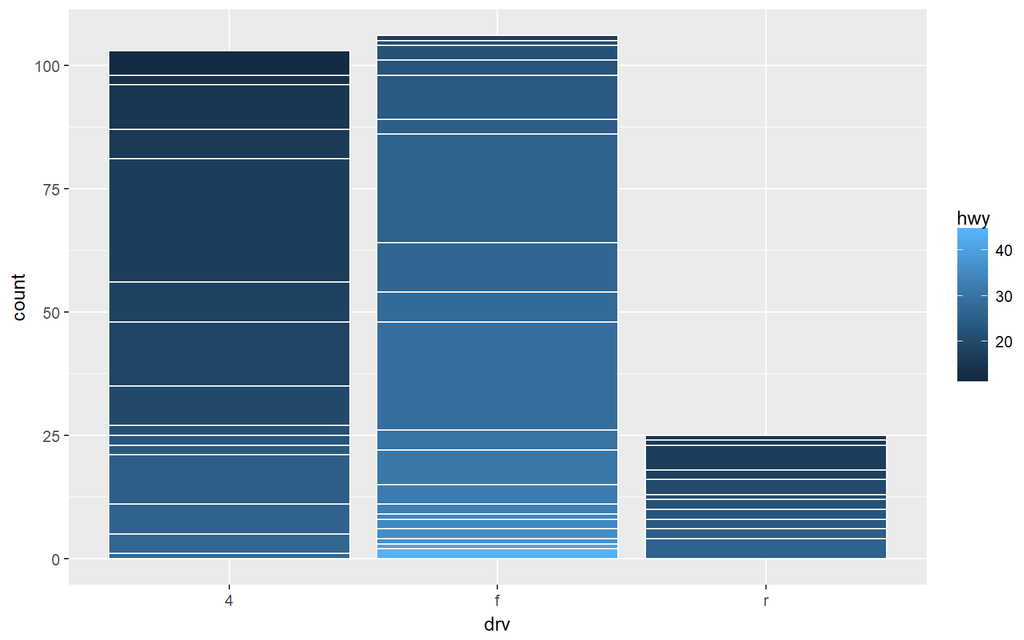

```r
ggplot(mpg, aes(drv, fill = hwy, group = hwy)) +
  geom_bar(colour = "white")
```

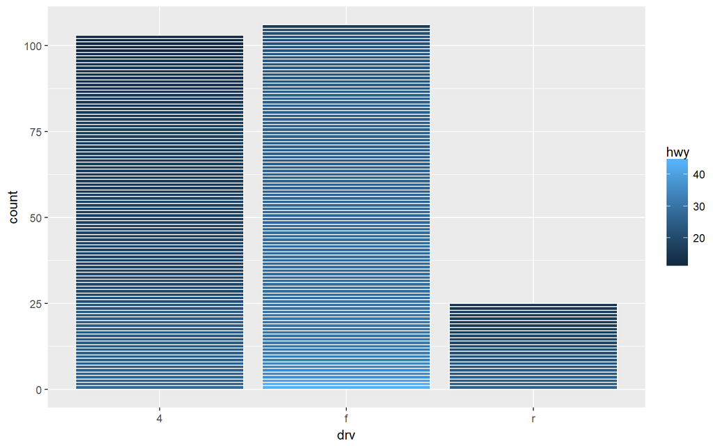

```r
library(dplyr)
mpg2 <- mpg %>% arrange(hwy) %>% mutate(id = seq_along(hwy))
ggplot(mpg2, aes(drv, fill = hwy, group = id)) +
  geom_bar(colour = "white")
```

윤곽선으로 응용을 할 수 있을까?

# 5 Drawing Maps

## 5.1 Vector Boundaries

Vector boundaries are defined by a data frame with one row for each “corner” of a geographical region like a country, state, or county. It requires four variables:

- **lat** and **long**, giving the location of a point
- **group**, a unique identifier for each contiguous region
- **id**, the name of the region

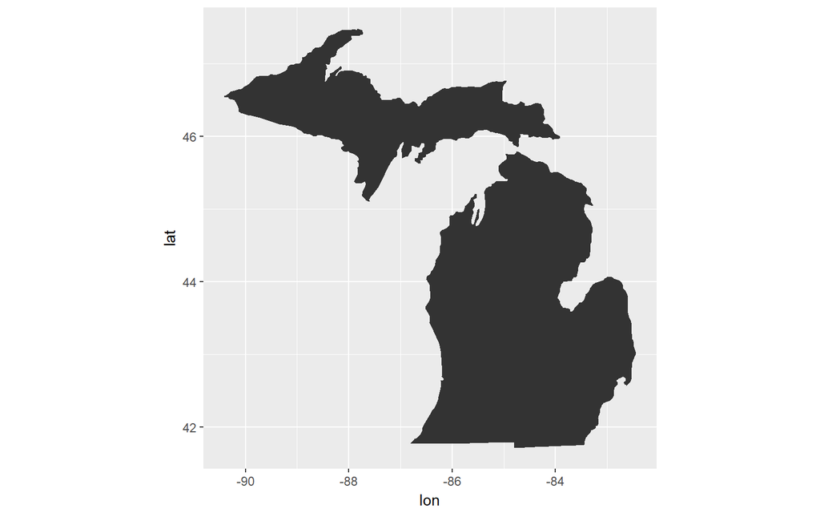

```r
mi_counties <- map_data("county", "michigan") %>%
  select(lon = long, lat, group, id = subregion)
ggplot(mi_counties, aes(lon, lat)) +
  geom_polygon(aes(group = group)) +
  coord_quickmap()
```

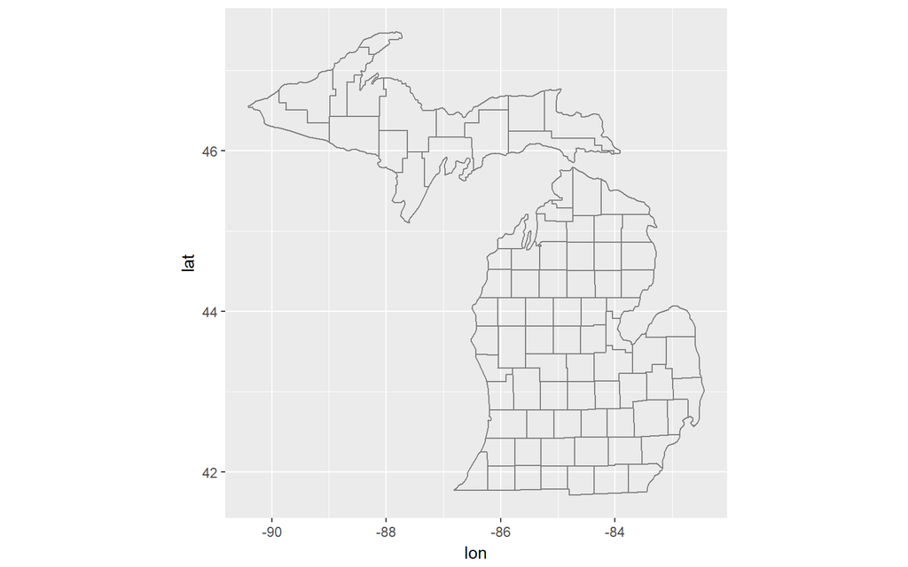

```r
ggplot(mi_counties, aes(lon, lat)) +
  geom_polygon(aes(group = group), fill = NA, colour = "grey50") +
  coord_quickmap()
```

USAboundaries package, tigris package, rnaturalearth package and osmar package

```r
library(USAboundaries)
c18 <- us_boundaries(as.Date("1820-01-01"))
c18df <- fortify(c18)
head(c18df)
```

## 5.2 Point Metadata

Point metadata connects locations (defined by lat and lon) with other variables

```r
mi_cities <- maps::us.cities %>%
  tbl_df() %>%
  filter(country.etc =="MI") %>%
  select(-country.etc, lon = long) %>%
  arrange(desc(pop))
mi_cities
```

```
## # A tibble: 36 x 5
##    name                   pop   lat   lon capital
##    <chr>                <int> <dbl> <dbl>   <int>
##  1 Detroit MI          871789  42.4 -83.1       0
##  2 Grand Rapids MI     193006  43.0 -85.7       0
##  3 Warren MI           132537  42.5 -83.0       0
##  4 Sterling Heights MI 127027  42.6 -83.0       0
##  5 Lansing MI          117236  42.7 -84.6       2
##  6 Flint MI            115691  43.0 -83.7       0
##  7 Ann Arbor MI        113716  42.3 -83.7       0
##  8 Clinton MI          100517  42.6 -82.9       0
##  9 Livonia MI           97722  42.4 -83.4       0
## 10 Dearborn MI          94681  42.3 -83.2       0
## # ... with 26 more rows
```

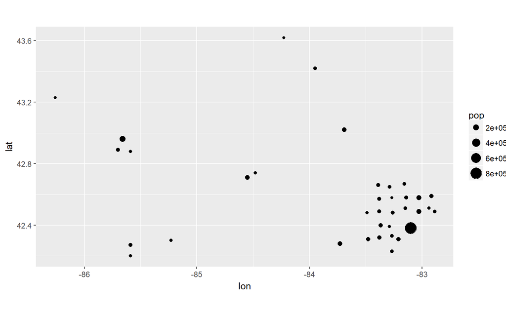

```r
ggplot(mi_cities, aes(lon, lat)) +
  geom_point(aes(size = pop)) +
  scale_size_area() +
  coord_quickmap() #지도가 안그려져 있어서 의미가 없다
```

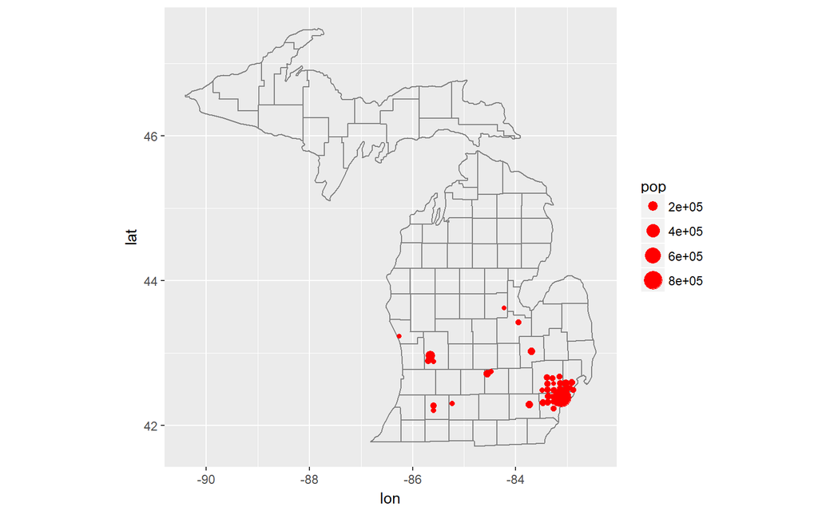

```r
ggplot(mi_cities, aes(lon, lat)) +
  geom_polygon(aes(group = group), mi_counties, fill = NA, colour = "grey50") +
  geom_point(aes(size = pop), colour = "red") +
  scale_size_area() +
  coord_quickmap()
```

## 5.3 Raster Images

Instead of displaying context with vector boundaries, you might want to draw a traditional map underneath

```r
if (file.exists("mi_raster.rds")) {
  mi_raster <- readRDS("mi_raster.rds")
} else {
  bbox <- c(
    min(mi_counties$lon), min(mi_counties$lat),
    max(mi_counties$lon), max(mi_counties$lat)
  )
  mi_raster <- ggmap::get_openstreetmap(bbox, scale = 8735660)
  saveRDS(mi_raster, "mi_raster.rds")
}
ggmap::ggmap(mi_raster)

ggmap::ggmap(mi_raster) +
  geom_point(aes(size = pop), mi_cities, colour = "red") +
  scale_size_area()
```

```r
df <- as.data.frame(raster::rasterToPoints(x))
names(df) <- c("lon", "lat", "x")
ggplot(df, aes(lon, lat)) +
  geom_raster(aes(fill = x))
```

## 5.4 Area Metadata

Sometimes metadata is associated not with a point, but with an area

```r
mi_census <- midwest %>%
  tbl_df() %>%
  filter(state =="MI") %>%
  mutate(county = tolower(county)) %>%
  select(county, area, poptotal, percwhite, percblack)
mi_census
```

```
## # A tibble: 83 x 5
##    county   area poptotal percwhite percblack
##    <chr>   <dbl>    <int>     <dbl>     <dbl>
##  1 alcona  0.041    10145      98.8    0.266
##  2 alger   0.051     8972      93.9    2.37
##  3 allegan 0.049    90509      95.9    1.60
##  4 alpena  0.034    30605      99.2    0.114
##  5 antrim  0.031    18185      98.4    0.126
##  6 arenac  0.021    14931      98.4    0.0670
##  7 baraga  0.054     7954      87.6    0.616
##  8 barry   0.034    50057      98.7    0.208
##  9 bay     0.026   111723      96.4    1.11
## 10 benzie  0.02     12200      97.2    0.246
## # ... with 73 more rows
```

공간 요소가 없기 때문에 이 데이터로 바로 매핑할 순 없다. 대신에, vector bundaries data에 합친다.

```r
census_counties <- left_join(mi_census, mi_counties, by = c("county" ="id"))
census_counties
```

```
## # A tibble: 1,472 x 8
##    county  area poptotal percwhite percblack   lon   lat group
##    <chr>  <dbl>    <int>     <dbl>     <dbl> <dbl> <dbl> <dbl>
##  1 alcona 0.041    10145      98.8     0.266 -83.9  44.9     1
##  2 alcona 0.041    10145      98.8     0.266 -83.4  44.9     1
##  3 alcona 0.041    10145      98.8     0.266 -83.4  44.9     1
##  4 alcona 0.041    10145      98.8     0.266 -83.3  44.8     1
##  5 alcona 0.041    10145      98.8     0.266 -83.3  44.8     1
##  6 alcona 0.041    10145      98.8     0.266 -83.3  44.8     1
##  7 alcona 0.041    10145      98.8     0.266 -83.3  44.7     1
##  8 alcona 0.041    10145      98.8     0.266 -83.3  44.7     1
##  9 alcona 0.041    10145      98.8     0.266 -83.3  44.7     1
## 10 alcona 0.041    10145      98.8     0.266 -83.3  44.6     1
## # ... with 1,462 more rows
```

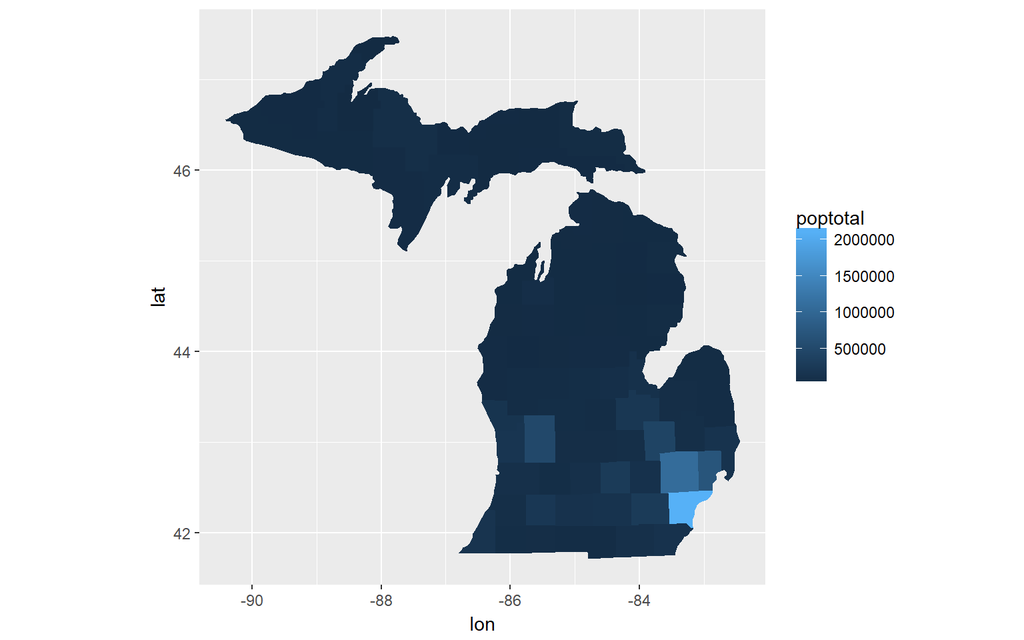

```r
ggplot(census_counties, aes(lon, lat, group = county)) +
  geom_polygon(aes(fill = poptotal)) +
  coord_quickmap()
```

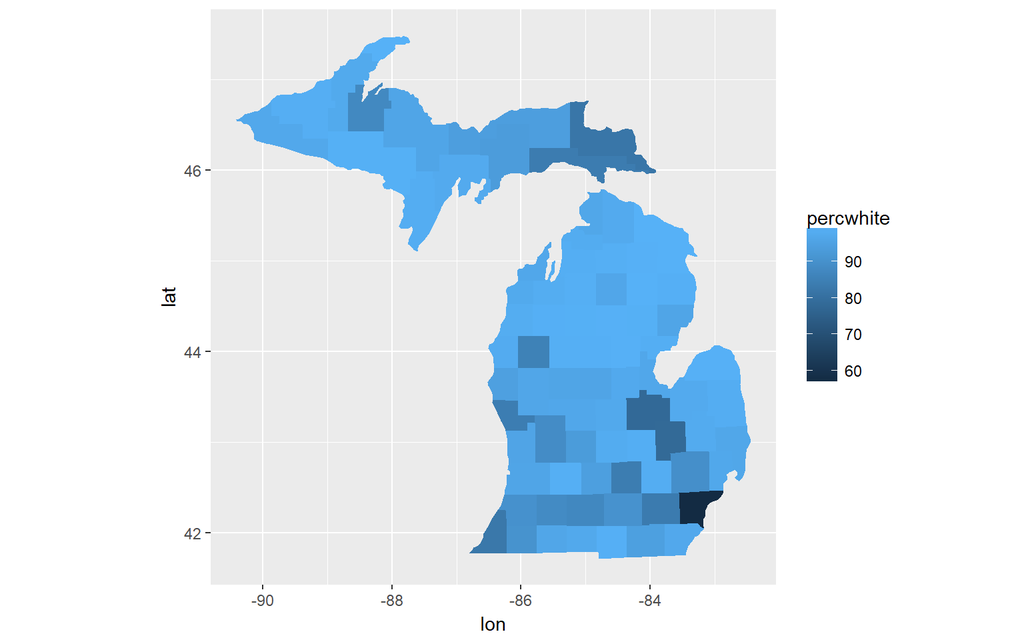

```r
ggplot(census_counties, aes(lon, lat, group = county)) +
  geom_polygon(aes(fill = percwhite)) +
  coord_quickmap()
```

# 6 Revealing Uncertainty

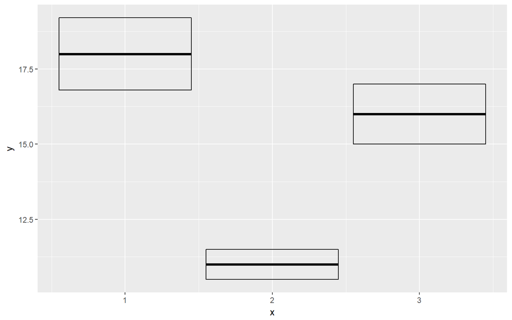

```r
y <- c(18, 11, 16)
df <- data.frame(x = 1:3, y = y, se = c(1.2, 0.5, 1.0))
base <- ggplot(df, aes(x, y, ymin = y - se, ymax = y + se))
base + geom_crossbar()
```

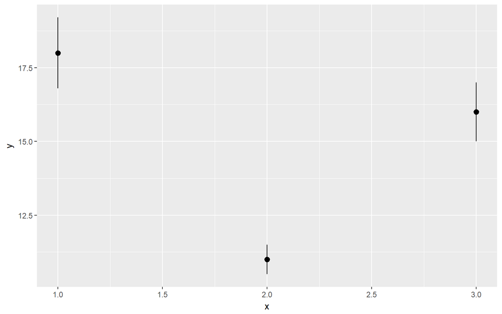

```r
base + geom_pointrange()
```

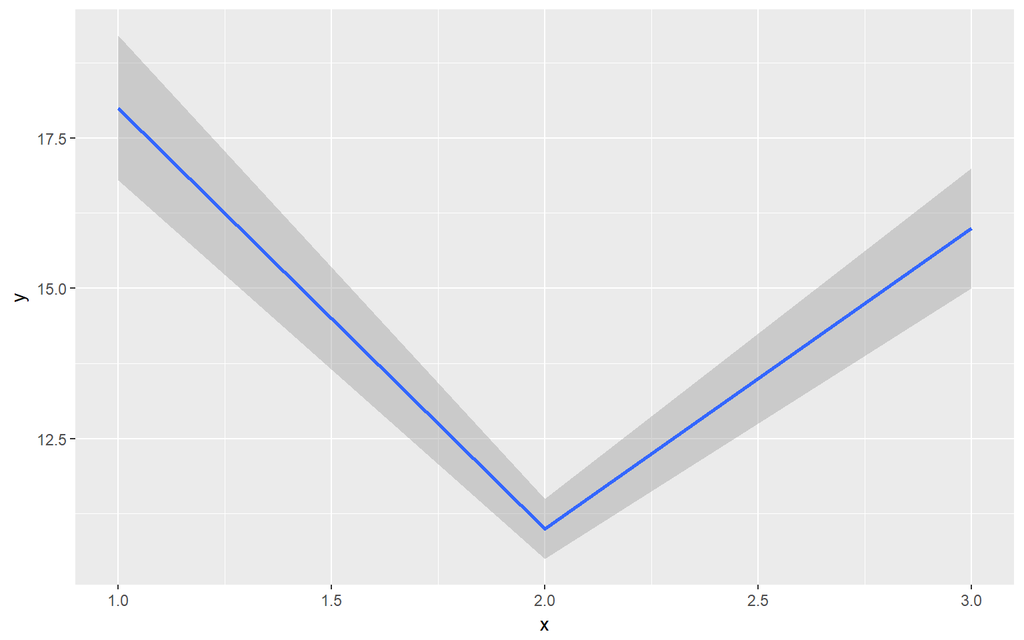

```r
base + geom_smooth(stat = "identity")
```

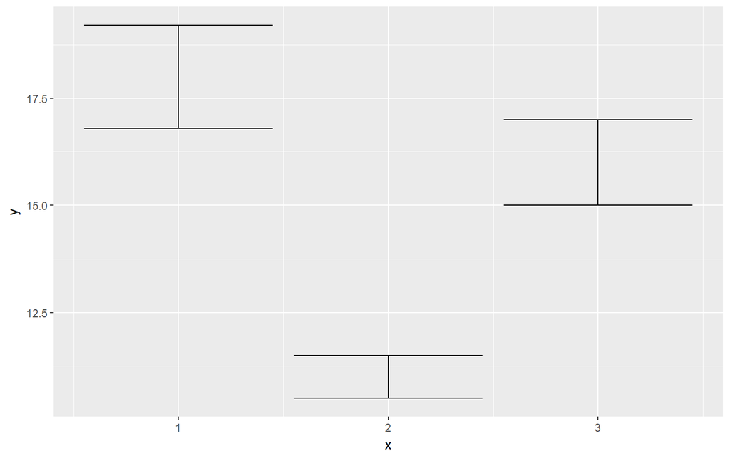

```r
base + geom_errorbar()
```

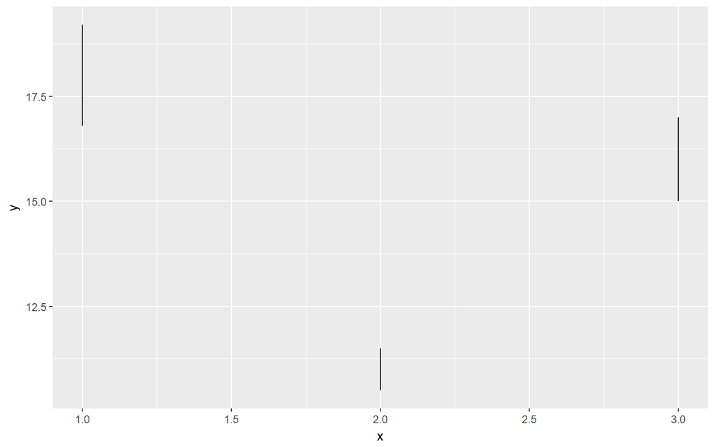

```r
base + geom_linerange()
```

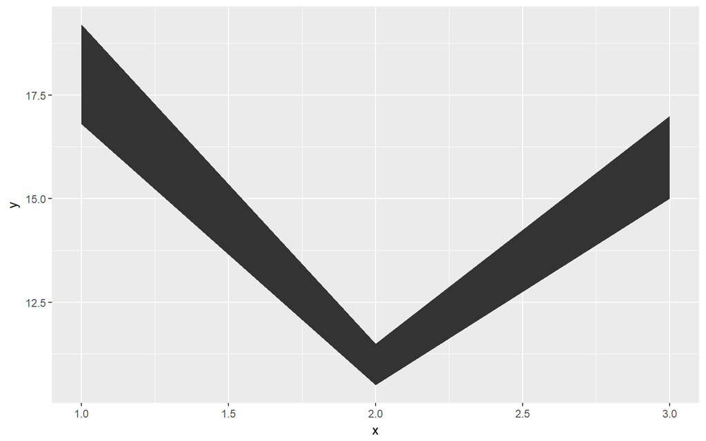

```r
base + geom_ribbon()
```

# 7 Weighted Data

When you have aggregated data where each row in the dataset represents multiple observations, you need some way to take into account the weighting variable.Weights are supported for every case where it makes sense: smoothers, quantile regressions, boxplots, histograms, and density plots.

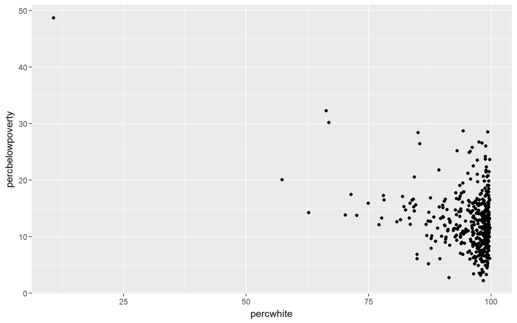

```r
# Unweighted
ggplot(midwest, aes(percwhite, percbelowpoverty)) +
  geom_point()
```

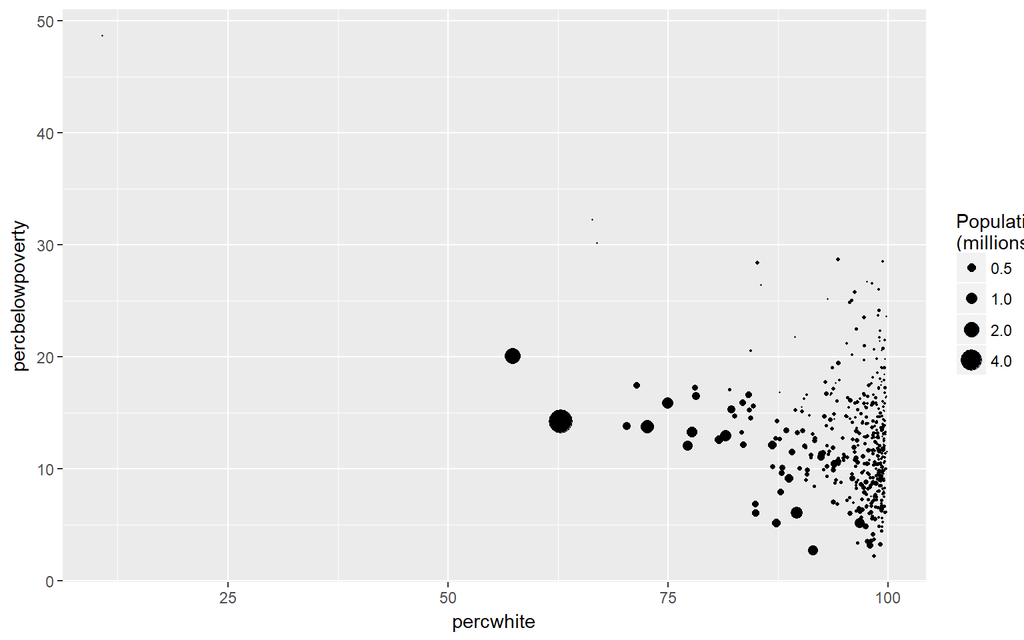

```r
# Weight by population
ggplot(midwest, aes(percwhite, percbelowpoverty)) +
  geom_point(aes(size = poptotal / 1e6)) +
  scale_size_area("Population\n(millions)", breaks = c(0.5, 1, 2, 4)) # breaks는 poptotal의 분포를 보고 알아서 정하자.
```

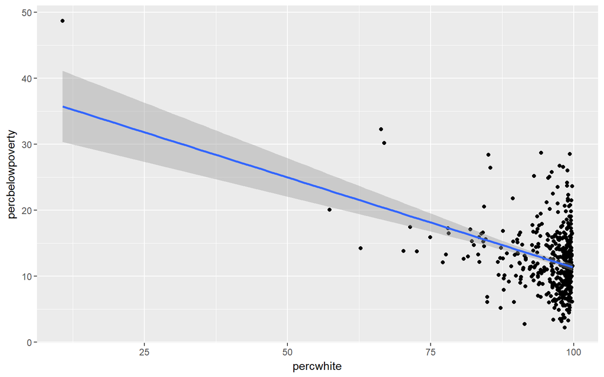

```r
# Unweighted
ggplot(midwest, aes(percwhite, percbelowpoverty)) +
  geom_point() +
  geom_smooth(method = lm, size = 1)
```

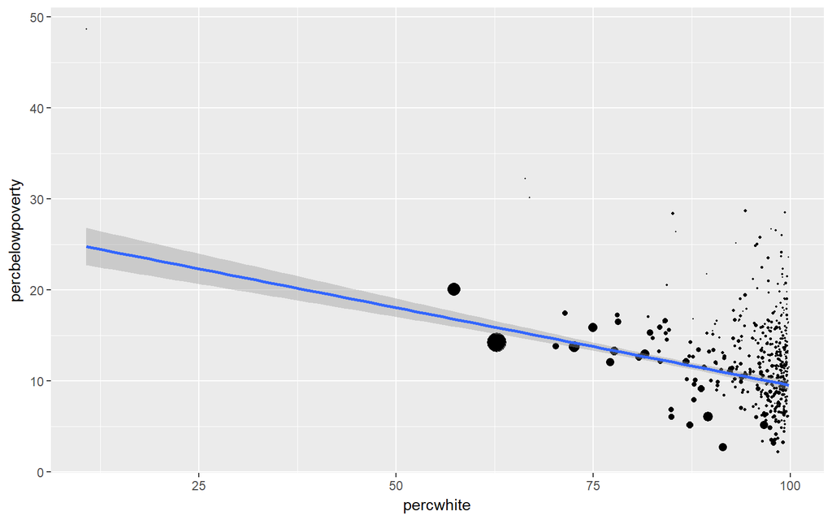

```r
# Weighted by population
ggplot(midwest, aes(percwhite, percbelowpoverty)) +
  geom_point(aes(size = poptotal / 1e6)) +
  geom_smooth(aes(weight = poptotal), method = lm, size = 1) +
  scale_size_area(guide = "none")
```

```r
midwest_model <- lm(percbelowpoverty ~ percwhite, weights =  poptotal, data = midwest)
summary(midwest_model)
```

```
##
## Call:
## lm(formula = percbelowpoverty ~ percwhite, data = midwest, weights = poptotal)
##
## Weighted Residuals:
##     Min      1Q  Median      3Q     Max
## -7300.7  -191.2   282.1   801.8  4754.5
##
## Coefficients:
##             Estimate Std. Error t value Pr(>|t|)
## (Intercept) 26.60176    1.18606   22.43   <2e-16 ***
## percwhite   -0.17089    0.01376  -12.42   <2e-16 ***
## ---
## Signif. codes:  0 '***' 0.001 '**' 0.01 '*' 0.05 '.' 0.1 ' ' 1
##
## Residual standard error: 1193 on 435 degrees of freedom
## Multiple R-squared:  0.2617, Adjusted R-squared:   0.26
## F-statistic: 154.2 on 1 and 435 DF,  p-value: < 2.2e-16
```

```r
midwest_model$coefficients #geom_smooth에서 weight는 가중회귀이다.
```

```
## (Intercept)   percwhite
##  26.6017579  -0.1708899
```

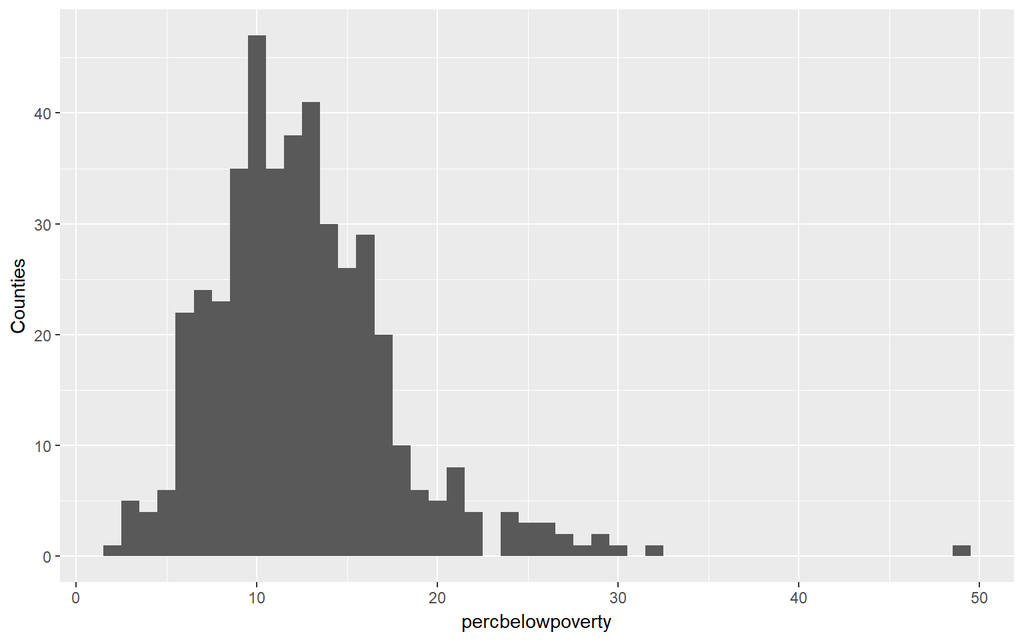

```r
ggplot(midwest, aes(percbelowpoverty)) +
  geom_histogram(binwidth = 1) +
  ylab("Counties")
```

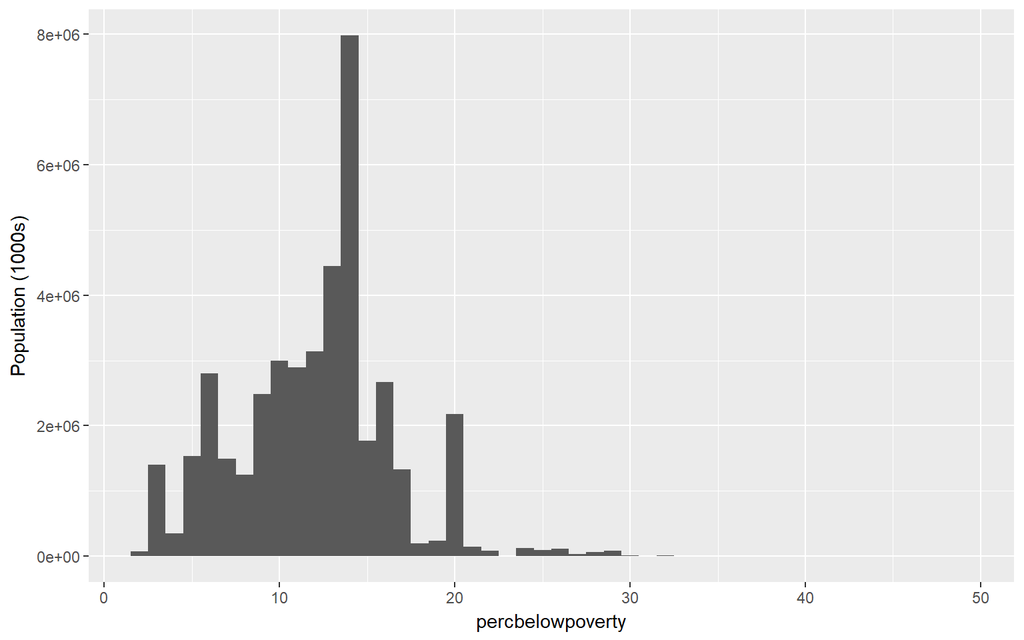

```r
ggplot(midwest, aes(percbelowpoverty)) +
  geom_histogram(aes(weight = poptotal), binwidth = 1) +
  ylab("Population (1000s)")
```

# 8 Displaying Distributions

parameter를 조정하여서 분포를 탐색하자.

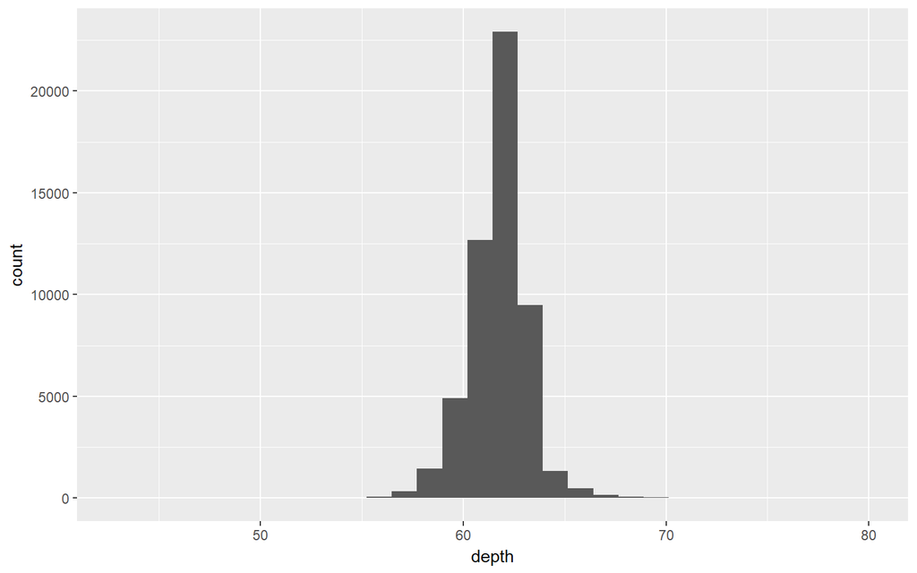

```r
ggplot(diamonds, aes(depth)) +
  geom_histogram()
```

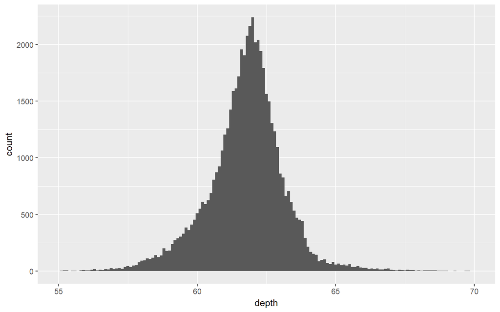

```r
ggplot(diamonds, aes(depth)) +
  geom_histogram(binwidth = 0.1) +
  xlim(55, 70)
```

The conditional density plot uses position fill() to stack each bin, scaling it to the same height. This plot is perceptually challenging because you need to compare bar heights, not positions, but you can see the strongest patterns.

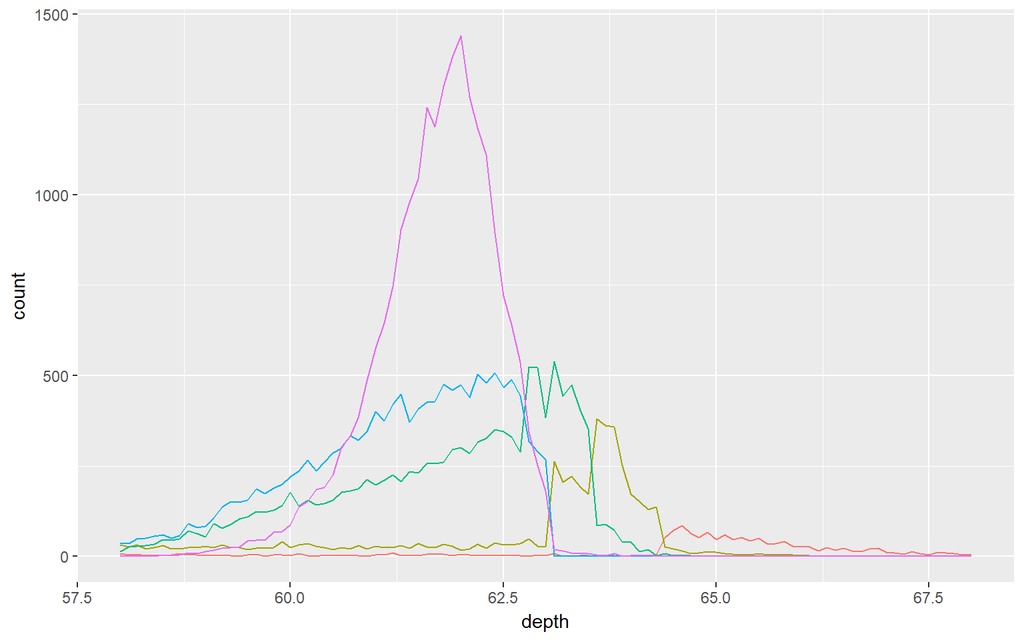

```r
ggplot(diamonds, aes(depth)) +
  geom_freqpoly(aes(colour = cut), binwidth = 0.1, na.rm = TRUE) +
  xlim(58, 68) + #
  theme(legend.position = "none")
```

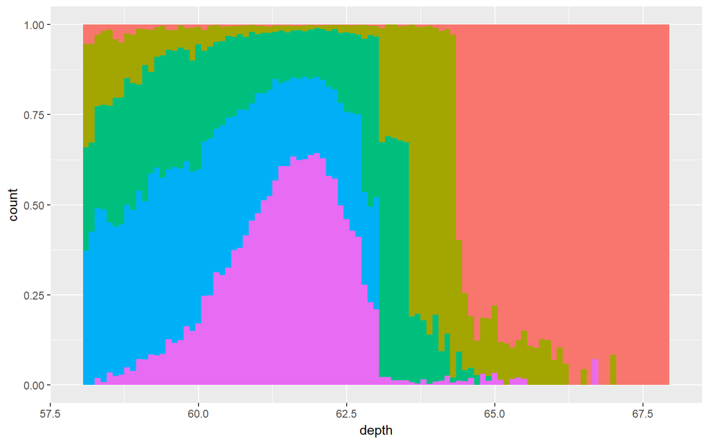

```r
ggplot(diamonds, aes(depth)) +
  geom_histogram(aes(fill = cut), binwidth = 0.1, position = "fill", na.rm = TRUE) + # conditional density plot, y축은 밀도
  xlim(58, 68) +
  theme(legend.position = "none")
```

Both the histogram and frequency polygon geom use the same underlying statistical transformation: stat = “bin”. This statistic produces two output variables: count and density.

bin-based 시각화의 대안은 밀도추정이다. 기본밀도가 smooth, 연속, 유계하지 않을 때 사용해라. adjust 인자는 밀도의 smooth를 조정한다 각 그룹을 밀도추정하게 되면 각 그룹이 상대적인 크기에 대한 정보는 사라진다는 것에 유의하자.

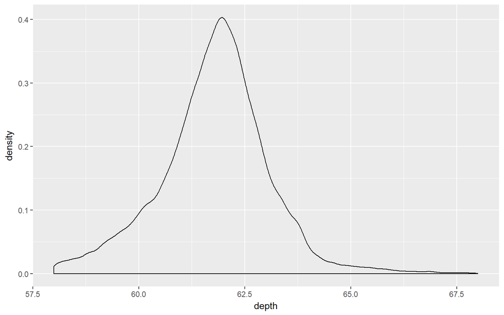

```r
ggplot(diamonds, aes(depth)) +
  geom_density(na.rm = TRUE) +
  xlim(58, 68) +
  theme(legend.position = "none")
```

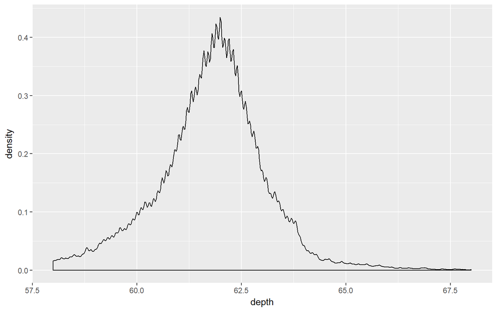

```r
ggplot(diamonds, aes(depth)) +
  geom_density(na.rm = TRUE, adjust = .4) +
  xlim(58, 68) +
  theme(legend.position = "none")
```

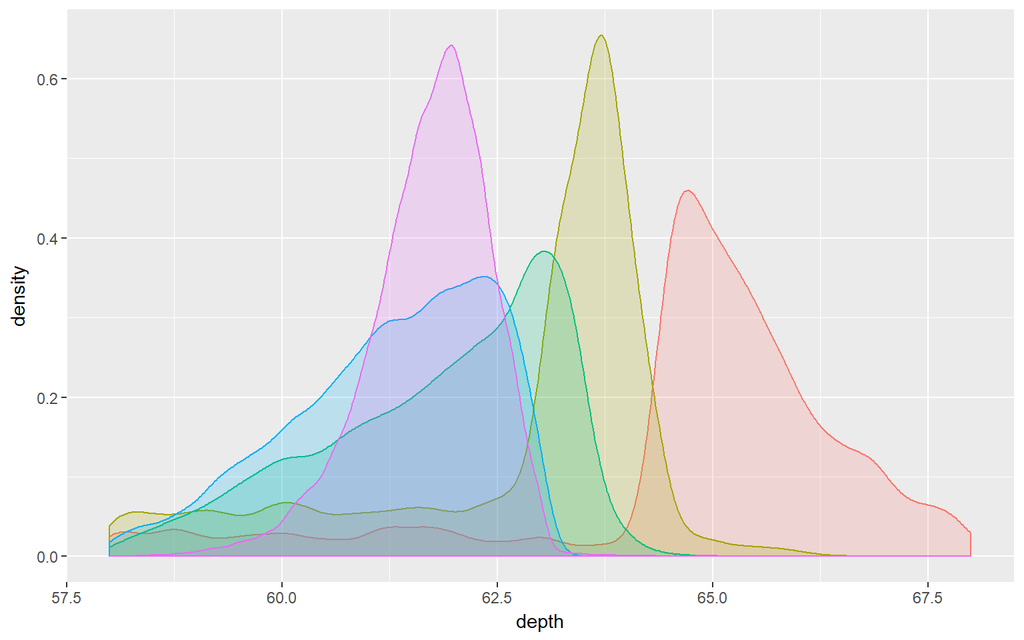

```r
ggplot(diamonds, aes(depth, fill = cut, colour = cut)) +
  geom_density(alpha = 0.2, na.rm = TRUE) +
  xlim(58, 68) +
  theme(legend.position = "none")
```

많은 분포들을 비교하기를 원할때는 질을 위하여 양을 희생할 수 있다. 유용한 helper 함수에는 `cut_width()`

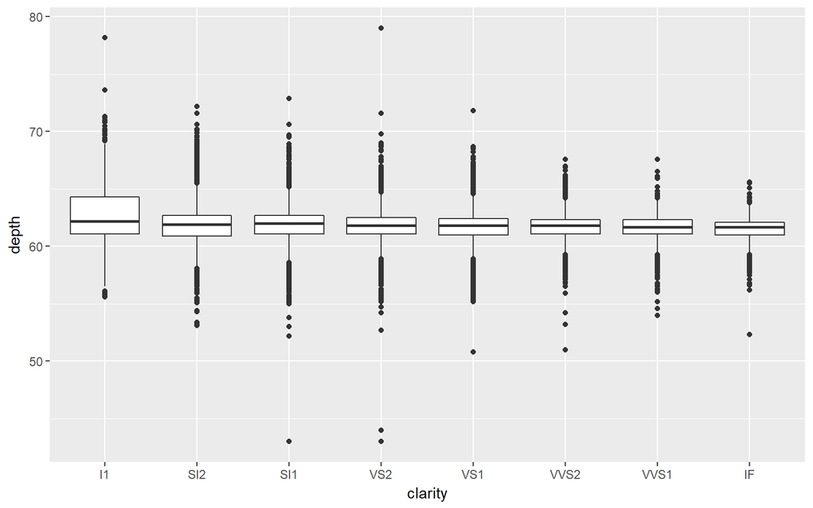

```r
ggplot(diamonds, aes(clarity, depth)) +
geom_boxplot()
```

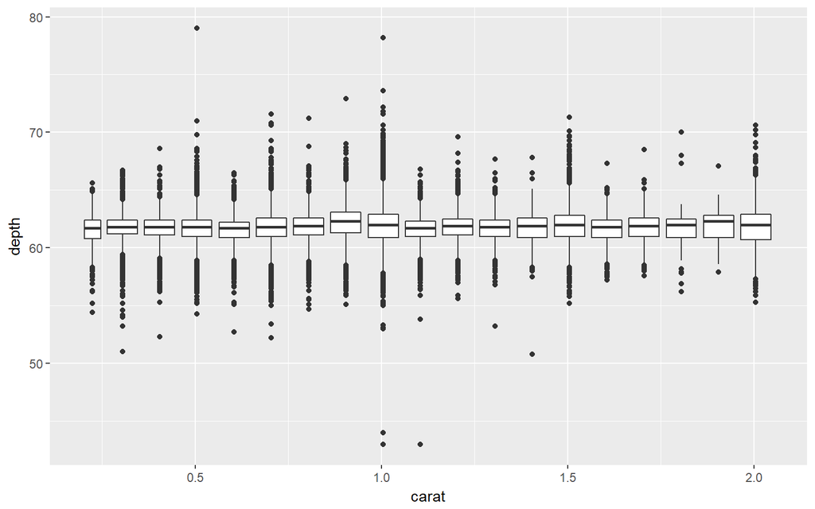

```r
ggplot(diamonds, aes(carat, depth)) +
geom_boxplot(aes(group = cut_width(carat, 0.1))) + # cut_width는 구간을 나누고 구간마다 레벨을 다르게 준다.
xlim(NA, 2.05)
```

`geom_vilolin()` 밀도 플랏의 압축 버전 `geom_dotplot()` 작은 데이터셋의 유용

## 8.1 Exercises

1. What binwidth tells you the most interesting story about the distribution of carat?

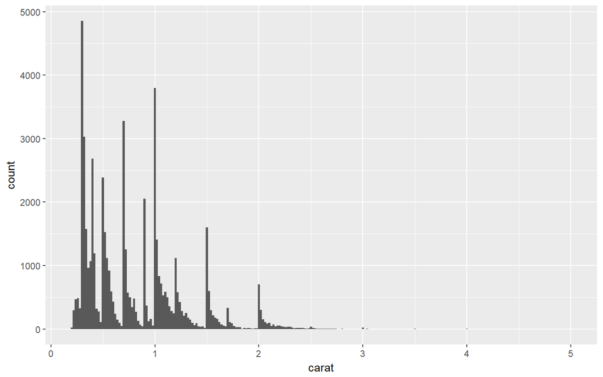

```r
ggplot(diamonds, aes(carat)) +
  geom_histogram(binwidth = 0.02)
```

결론 : histogram을 통해 분포를 확인할 때는 bin을 꼭 적절하게 나눠보는 노력을 하자

2. How does the distribution of price vary with clarity?

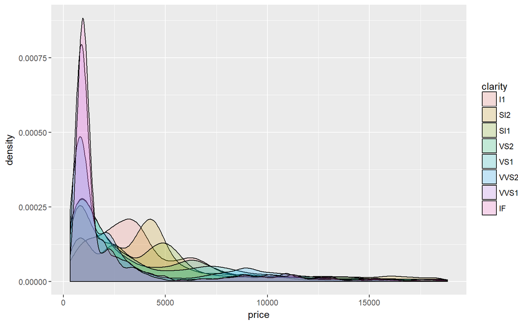

```r
ggplot(diamonds, aes(price)) +
  geom_density(aes(fill = clarity), alpha = 1/5)
```

clarity가 좋은 다이아몬드가 오히려 가격이 작아 보인다. 정말로 이런 경향을 띄는지 좀 더 분석해 봐야 알 것 같다.

3. Overlay a frequency polygon and density plot of depth. What computed variable do you need to map to y to make the two plots comparable? (You can either modify geom freqpoly() or geom density().)

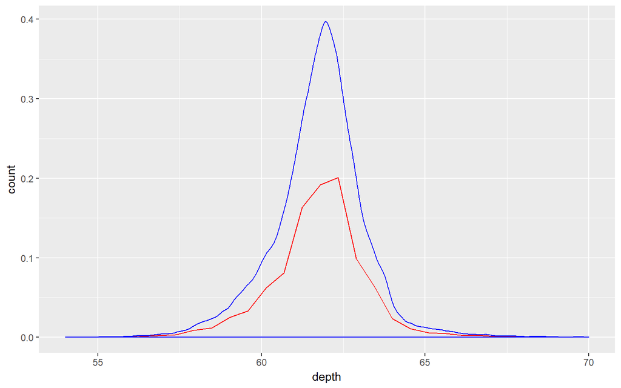

```r
ggplot(diamonds) +
  geom_freqpoly(aes(depth, weight = 1/nrow(diamonds)), colour = "red") +
  geom_density(aes(depth), colour = "blue") +
  xlim(54, 70)
```

Those are frequency polygons (based on binned counts) & densities from a kernel density estimator (as from geom_density).

# 9 Dealing with Overplotting

데이터가 작을 때

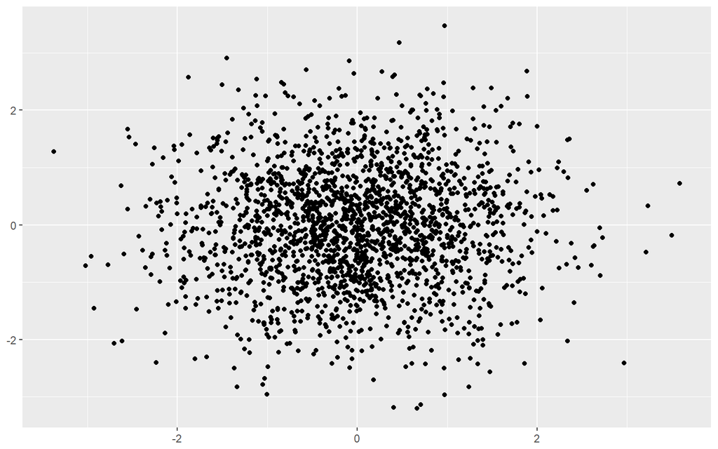

```r
df <- data.frame(x = rnorm(2000), y = rnorm(2000))
norm <- ggplot(df, aes(x, y)) + xlab(NULL) + ylab(NULL)
norm + geom_point()
```

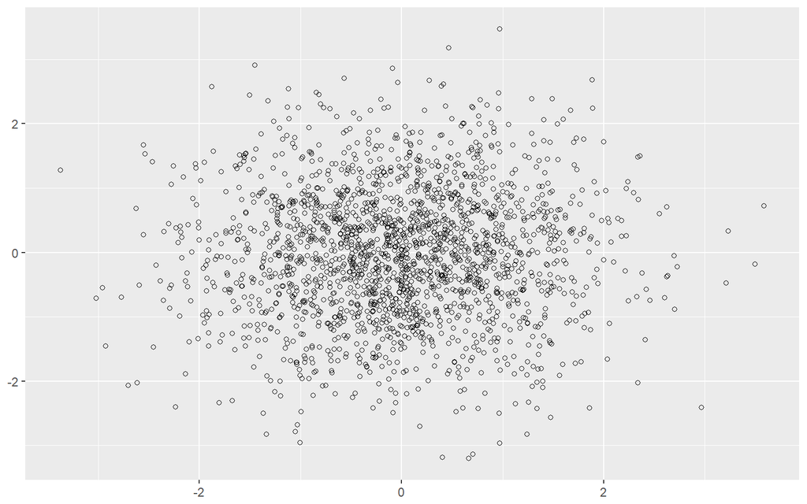

```r
norm + geom_point(shape = 1) # Hollow circles
```

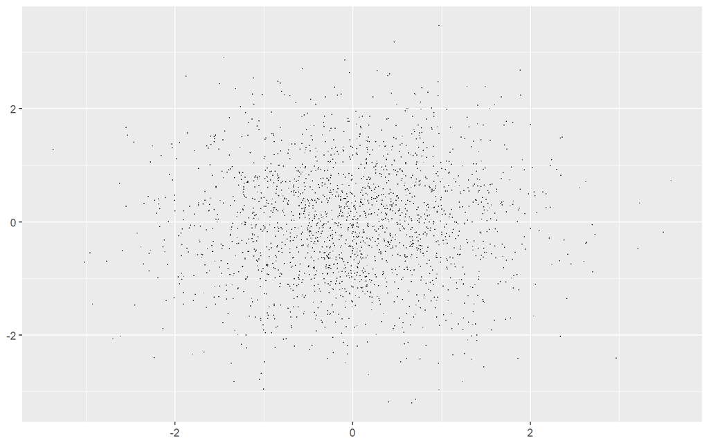

```r
norm + geom_point(shape = ".") # Pixel sized
```

데이터가 클 때

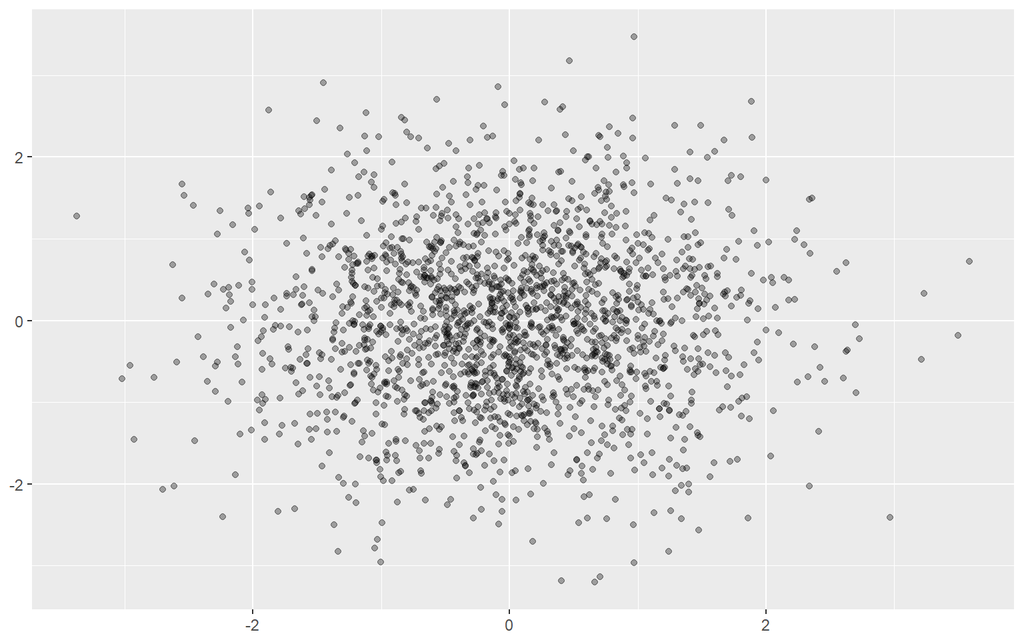

```r
norm + geom_point(alpha = 1 / 3)
```

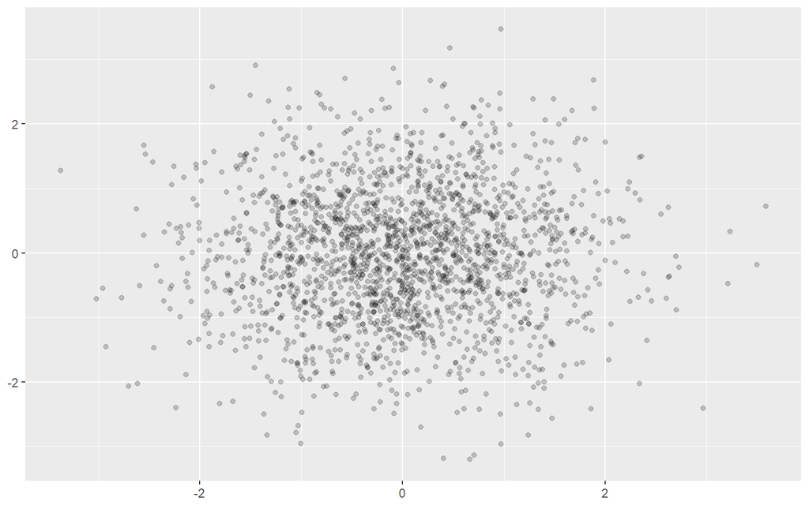

```r
norm + geom_point(alpha = 1 / 5)
```

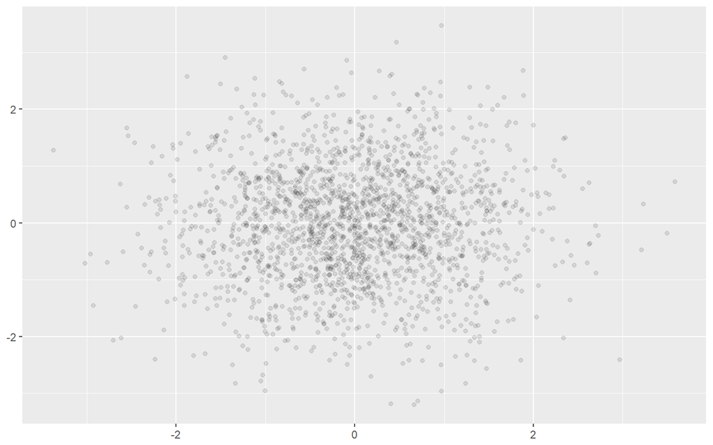

```r
norm + geom_point(alpha = 1 / 10)
```

데이터에 약간의 discreteness가 있다면 `geom_jitter()` By default, the amount of jitter added is 40% of the resolution of the data, which leaves a small gap between adjacent regions.

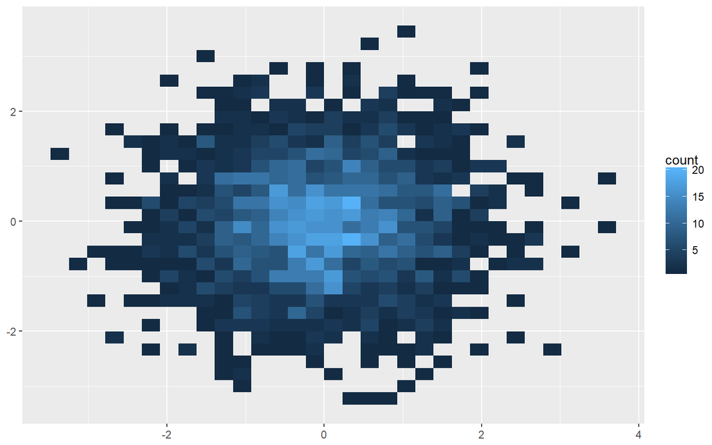

```r
norm + geom_bin2d()
```

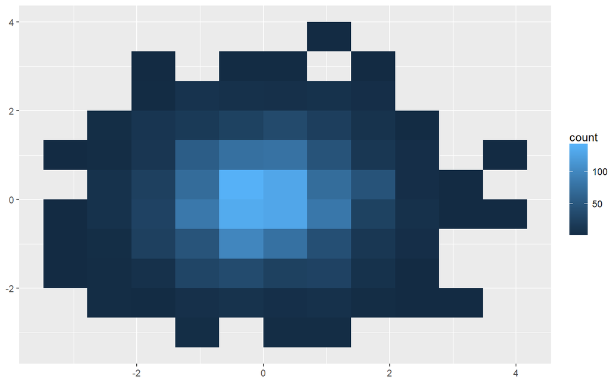

```r
norm + geom_bin2d(bins = 10)
```

bins : numeric vector giving number of bins in both vertical and horizontal directions. Set to 30 by default.

육각형이 좀 더 나아보인다.

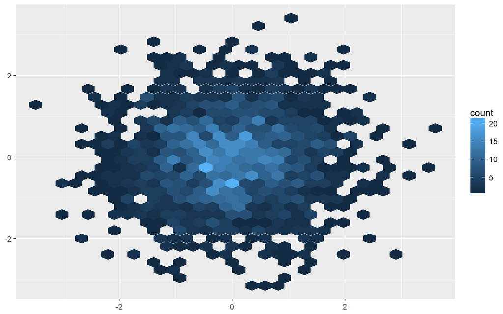

```r
#install.packages("hexbin")
norm + geom_hex()
```

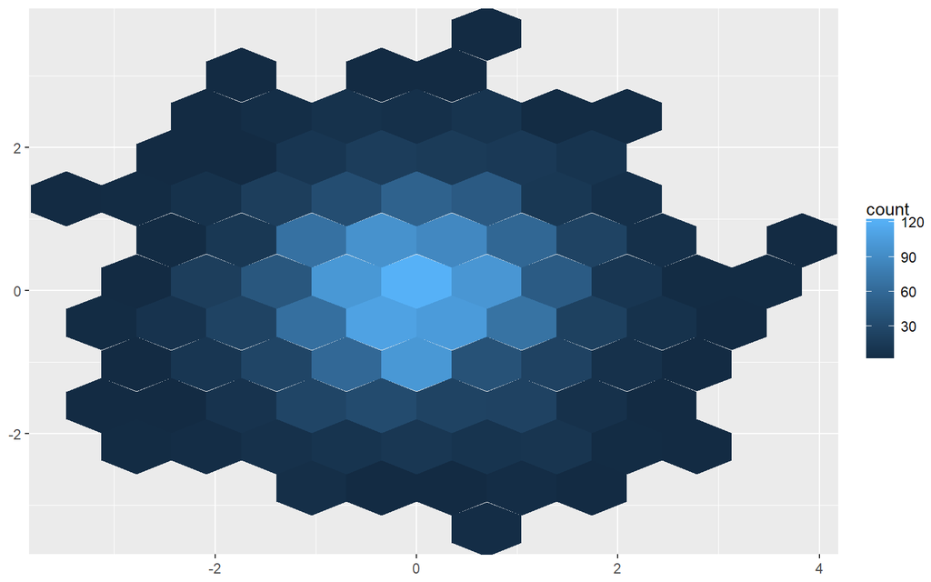

```r
norm + geom_hex(bins = 10)
```

# 10 Statistical Summaries

데이터조작없이 빠르게 그릴 수 있다는 것이 장점이다.

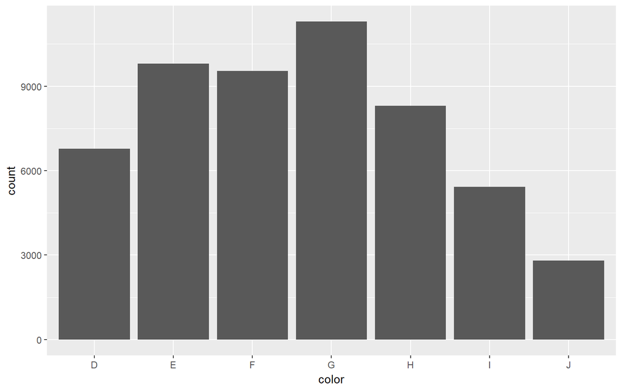

```r
ggplot(diamonds, aes(color)) +
  geom_bar()
```

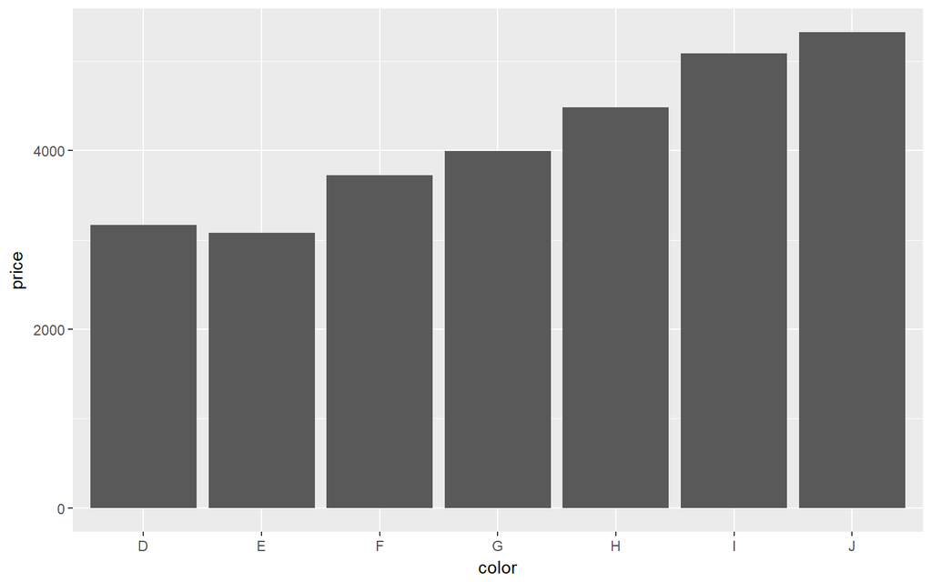

```r
ggplot(diamonds, aes(color, price)) +
  geom_bar(stat = "summary_bin", fun.y = mean) # 기억해두자
```

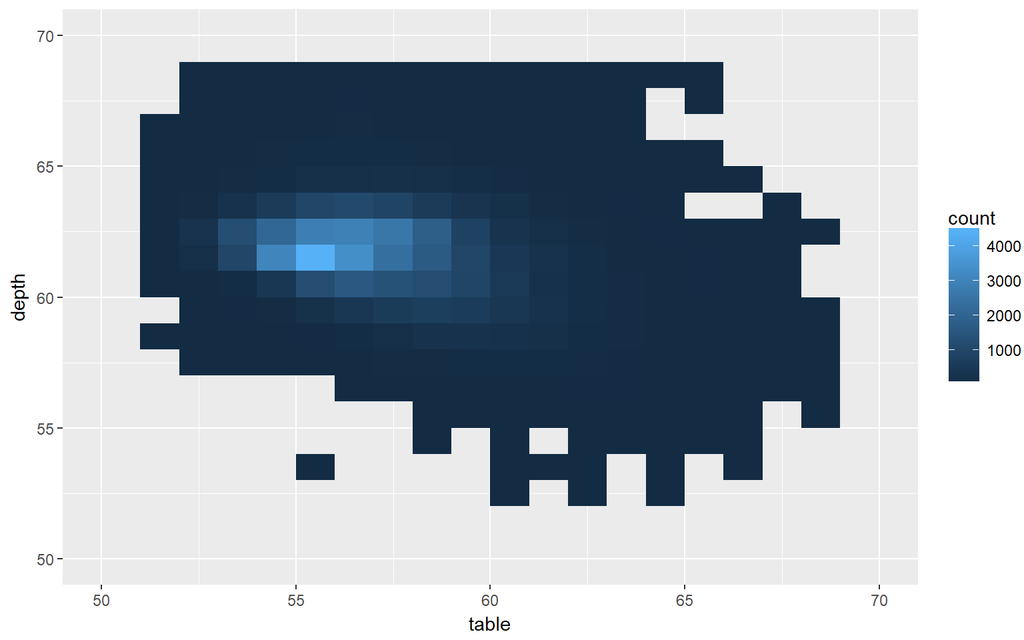

```r
ggplot(diamonds, aes(table, depth)) +
  geom_bin2d(binwidth = 1, na.rm = TRUE) +
  xlim(50, 70) +
  ylim(50, 70)
```

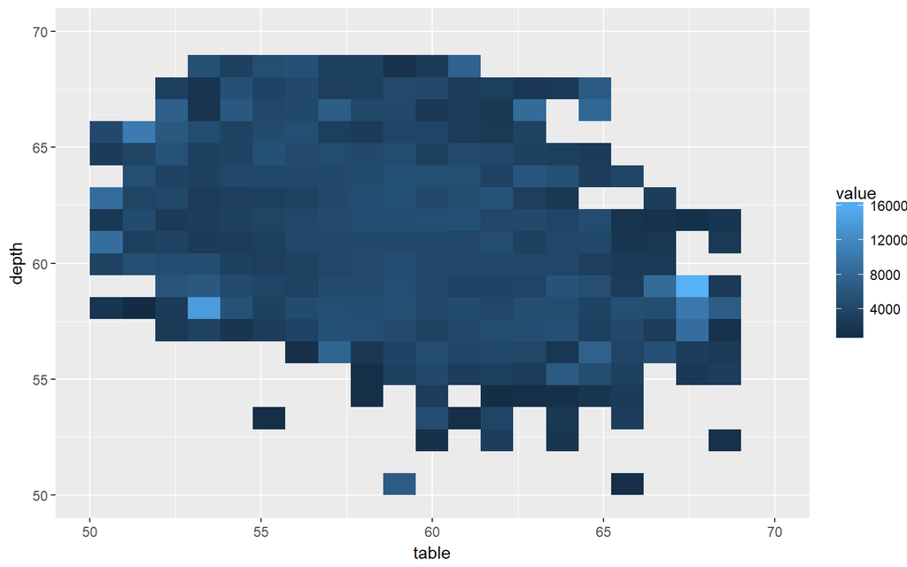

```r
ggplot(diamonds, aes(table, depth, z = price)) +
  geom_raster(binwidth = 1, stat = "summary_2d", fun = mean,
  na.rm = TRUE) +
  xlim(50, 70) +
  ylim(50, 70)
```

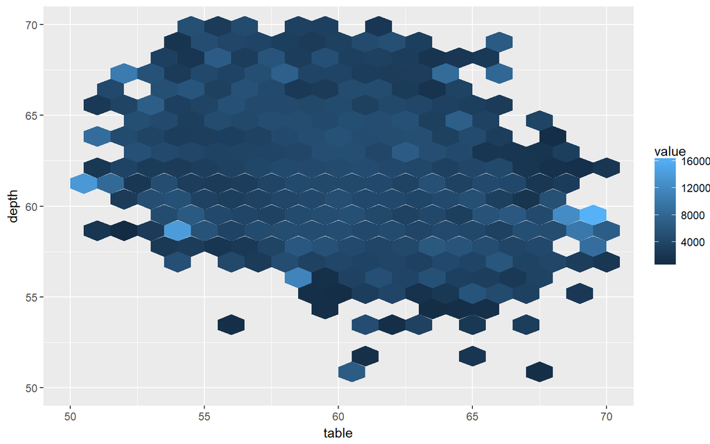

```r
ggplot(diamonds, aes(table, depth, z = price)) +
  geom_hex(binwidth = 1, stat = "summary_hex", fun = mean,
  na.rm = TRUE) +
  xlim(50, 70) +
  ylim(50, 70)
```

# 11 Summary

- geom_text대신 `ggrepel::geom_text_repel()`을 사용해보자. 다른 geom과 마찬가지로 aes(color, size, label)등 사용가능하다. `ggrepel::geom_label_repel()` 도 있다.
- 플랏에 메타데이터를 활용해보자
- 플랏에 회귀선을 넣으면 좀 더 좋을 수 있다.
- group 인자를 적절하게 사용하자
- x가 연속형 변수일 때 `cut_width()` 를 사용하여 boxplot을 그릴 수 있다.
- stat = “”, fun = 를 적절히 사용하자